# JMJPFU_Clustering

# JMJPFU

### 13-Feb-2017

In this Notebook, we will try out Non Supervised learning methods for the problem. We will try to do the following

1. Clustering models - KNN & Hierarchical clustering
2. Transformation of data set and observation of results
3. Tuning of the KNN & Hierarchical clustering models
4. Association mining of the data set.

## Clustering Models - KNN

Let us start with the KNN models

### Initial tasks : Loading the library files

```r
library(caret)
library(dplyr)
library(ggplot2)
```

### Step 1 : Defining the Train control and metrics

```r
trainCon <- trainControl(method="repeatedcv",number=10,repeats = 3)
metric = "Accuracy"
```

### Step 2 : Building the baseline model

```r
seed = 7
set.seed(seed)
# Building the model
knnModel <- train(label~.,data=xTrain,metric=metric,method='knn',trControl=trainCon)
summary(knnModel)
```

```
            Length Class      Mode
learn        2     -none-     list
k            1     -none-     numeric
theDots      0     -none-     list
xNames      11     -none-     character
problemType  1     -none-     character
tuneValue    1     data.frame list
obsLevels    9     -none-     character
```

### Step 3 : First prediction with the baseline model

```r
set.seed(seed)
# Prediction
knnpred <- knn3Train(xTrain[,1:11],xVal[,1:11],xTrain$label,k=9,prob=FALSE)
# Doing the confusion matrix
confusionMatrix(knnpred,xVal$label)
```

```
Confusion Matrix and Statistics

                      Reference
Prediction             FailurePoint NormalPeriod PeriodbeforeFailure1 PeriodbeforeFailure2 PeriodbeforeFailure3
  FailurePoint                   41            1                    0                    0                    0
  NormalPeriod                    9         1636                   13                   14                    0
  PeriodbeforeFailure1            0            1                   10                    7                    2
  PeriodbeforeFailure2            2            4                   20                   25                   15
  PeriodbeforeFailure3            0            1                    4                    4                   22
  PeriodbeforeFailure4            0            1                    0                    0                    2
  PeriodbeforeFailure5            0            2                    2                    1                    4
  PeriodbeforeFailure6            0            1                    0                    0                    0
  PeriodbeforeFailure7            0            0                    0                    0                    0
                      Reference
Prediction             PeriodbeforeFailure4 PeriodbeforeFailure5 PeriodbeforeFailure6 PeriodbeforeFailure7
  FailurePoint                            0                    0                    0                    0
  NormalPeriod                            0                    4                   23                   25
  PeriodbeforeFailure1                    0                    2                    0                    0
  PeriodbeforeFailure2                    0                   12                    0                    0
  PeriodbeforeFailure3                    4                    8                    0                    0
  PeriodbeforeFailure4                   42                    3                    2                    0
  PeriodbeforeFailure5                    0                   21                    9                    0
  PeriodbeforeFailure6                    0                    1                    4                    0
  PeriodbeforeFailure7                    0                    0                   10                   23

Overall Statistics

               Accuracy : 0.8954
                 95% CI : (0.8813, 0.9084)
    No Information Rate : 0.8085
    P-Value [Acc > NIR] : < 2.2e-16

                  Kappa : 0.6649
 Mcnemar's Test P-Value : NA

Statistics by Class:

                     Class: FailurePoint Class: NormalPeriod Class: PeriodbeforeFailure1 Class: PeriodbeforeFailure2
Sensitivity                      0.78846              0.9933                    0.204082                     0.49020
Specificity                      0.99950              0.7744                    0.993964                     0.97331
```

[output cut: 9 more lines]

```
Pos Pred Value                           0.51163                     0.84000                     0.53846
Neg Pred Value                           0.98847                     0.99799                     0.98498
Prevalence                               0.02209                     0.02258                     0.02504
Detection Rate                           0.01080                     0.02062                     0.01031
Detection Prevalence                     0.02111                     0.02455                     0.01915
Balanced Accuracy                        0.73917                     0.95451                     0.70135
                     Class: PeriodbeforeFailure6 Class: PeriodbeforeFailure7
Sensitivity                             0.083333                     0.47917
Specificity                             0.998994                     0.99497
Pos Pred Value                          0.666667                     0.69697
Neg Pred Value                          0.978336                     0.98752
Prevalence                              0.023564                     0.02356
Detection Rate                          0.001964                     0.01129
Detection Prevalence                    0.002946                     0.01620
Balanced Accuracy                       0.541164                     0.73707
```

As seen from the predictions, the accuracy and sensitivity values of all other classes are not that promising. We will try tuning the model and checking the results.

## JMJPFU

### 14-Feb-2017

Let us do the following

1. Continue with tuning of KNN
2. Explore other methods of clustering

### Step 4 : Tuning the parameters with grid

```r
trainCon <- trainControl(method="repeatedcv",number=10,repeats=3)
metric <- 'Accuracy'
set.seed(7)
grid <- expand.grid(.k=seq(1,20,by=1))
knnModel2 <- train(label~.,data=xTrain,method='knn',metric=metric,trControl=trainCon,tuneGrid=grid)
print(knnModel2)
```

```
k-Nearest Neighbors

8166 samples
  11 predictor
   9 classes: 'FailurePoint', 'NormalPeriod', 'PeriodbeforeFailure1', 'PeriodbeforeFailure2', 'PeriodbeforeFailure3', 'PeriodbeforeFailure4', 'PeriodbeforeFailure5', 'PeriodbeforeFailure6', 'PeriodbeforeFailure7'

No pre-processing
Resampling: Cross-Validated (10 fold, repeated 3 times)
Summary of sample sizes: 7350, 7347, 7349, 7349, 7351, 7351, ...
Resampling results across tuning parameters:

  k   Accuracy   Kappa
   1  0.9337914  0.8065192
   2  0.9237484  0.7772137
   3  0.9230151  0.7726593
   4  0.9221149  0.7679219
   5  0.9203200  0.7614195
   6  0.9192593  0.7574379
   7  0.9186467  0.7547708
   8  0.9166046  0.7482912
   9  0.9148910  0.7429186
  10  0.9132989  0.7378528
  11  0.9123592  0.7352176
  12  0.9114192  0.7321355
  13  0.9098693  0.7269884
  14  0.9093800  0.7254718
  15  0.9089303  0.7236456
  16  0.9081555  0.7210654
  17  0.9075841  0.7189214
  18  0.9070931  0.7167795
  19  0.9053800  0.7112461
  20  0.9043992  0.7078208

Accuracy was used to select the optimal model using  the largest value.
The final value used for the model was k = 1.
```

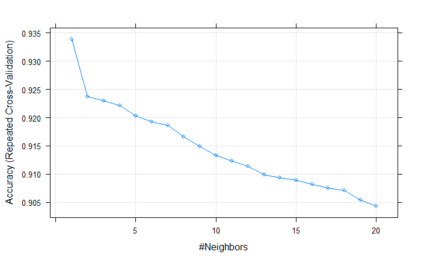

```r
plot(knnModel2)
```

Let us now predict with the learned parametes

```r
knnPred2 <- knn3Train(xTrain[,1:11],xVal[,1:11],xTrain$label,k=1,prob=FALSE)
confusionMatrix(knnPred2,xVal$label)
```

```
Confusion Matrix and Statistics

                      Reference
Prediction             FailurePoint NormalPeriod PeriodbeforeFailure1 PeriodbeforeFailure2 PeriodbeforeFailure3
  FailurePoint                   36           28                    6                    3                    0
  NormalPeriod                   12         1561                    9                    7                   10
  PeriodbeforeFailure1            3           34                    8                   16                    2
  PeriodbeforeFailure2            1           11                   17                   16                   13
  PeriodbeforeFailure3            0            1                    5                    3                   13
  PeriodbeforeFailure4            0            1                    0                    0                    0
  PeriodbeforeFailure5            0            2                    4                    6                    7
  PeriodbeforeFailure6            0            9                    0                    0                    0
  PeriodbeforeFailure7            0            0                    0                    0                    0
                      Reference
Prediction             PeriodbeforeFailure4 PeriodbeforeFailure5 PeriodbeforeFailure6 PeriodbeforeFailure7
  FailurePoint                            0                    0                    0                    0
  NormalPeriod                            7                    7                   14                   22
  PeriodbeforeFailure1                    0                    3                    0                    0
  PeriodbeforeFailure2                    0                   13                    0                    0
  PeriodbeforeFailure3                    3                    4                    0                    0
  PeriodbeforeFailure4                   36                    0                    1                    0
  PeriodbeforeFailure5                    0                   24                    1                    0
  PeriodbeforeFailure6                    0                    0                   22                    0
  PeriodbeforeFailure7                    0                    0                   10                   26

Overall Statistics

               Accuracy : 0.8552
                 95% CI : (0.8391, 0.8702)
    No Information Rate : 0.8085
    P-Value [Acc > NIR] : 1.886e-08

                  Kappa : 0.5751
 Mcnemar's Test P-Value : NA

Statistics by Class:

                     Class: FailurePoint Class: NormalPeriod Class: PeriodbeforeFailure1 Class: PeriodbeforeFailure2
Sensitivity                      0.69231              0.9478                    0.163265                    0.313725
Specificity                      0.98136              0.7744                    0.970825                    0.972306
```

[output cut: 9 more lines]

```
Pos Pred Value                          0.448276                     0.94737                     0.54545
Neg Pred Value                          0.984064                     0.99500                     0.98645
Prevalence                              0.022091                     0.02258                     0.02504
Detection Rate                          0.006382                     0.01767                     0.01178
Detection Prevalence                    0.014237                     0.01865                     0.02160
Balanced Accuracy                       0.640428                     0.89080                     0.73026
                     Class: PeriodbeforeFailure6 Class: PeriodbeforeFailure7
Sensitivity                              0.45833                     0.54167
Specificity                              0.99548                     0.99497
Pos Pred Value                           0.70968                     0.72222
Neg Pred Value                           0.98704                     0.98901
Prevalence                               0.02356                     0.02356
Detection Rate                           0.01080                     0.01276
Detection Prevalence                     0.01522                     0.01767
Balanced Accuracy                        0.72690                     0.76832
```

Its not a great model. The accuracy after the grid search has come down also the sensitivity for a lot of the classes has taken a dip.

Let us now try with the preprocessed data for training. Let us try the YeoJohnson transformed data and see how it fares in terms of predictions.

```r
set.seed(7)
knnPred3 <- knn3Train(xTrainTran[,1:11],xValTran[,1:11],xTrainTran$label,k=1,prob = FALSE)
confusionMatrix(knnPred3,xValTran$label)
```

```
Confusion Matrix and Statistics

                      Reference
Prediction             FailurePoint NormalPeriod PeriodbeforeFailure1 PeriodbeforeFailure2 PeriodbeforeFailure3
  FailurePoint                   36           28                    6                    3                    0
  NormalPeriod                   12         1561                    9                    7                   10
  PeriodbeforeFailure1            3           34                    8                   16                    2
  PeriodbeforeFailure2            1           11                   17                   16                   13
  PeriodbeforeFailure3            0            1                    5                    3                   13
  PeriodbeforeFailure4            0            1                    0                    0                    0
  PeriodbeforeFailure5            0            2                    4                    6                    7
  PeriodbeforeFailure6            0            9                    0                    0                    0
  PeriodbeforeFailure7            0            0                    0                    0                    0
                      Reference
Prediction             PeriodbeforeFailure4 PeriodbeforeFailure5 PeriodbeforeFailure6 PeriodbeforeFailure7
  FailurePoint                            0                    0                    0                    0
  NormalPeriod                            7                    7                   14                   22
  PeriodbeforeFailure1                    0                    3                    0                    0
  PeriodbeforeFailure2                    0                   13                    0                    0
  PeriodbeforeFailure3                    3                    4                    0                    0
  PeriodbeforeFailure4                   36                    0                    1                    0
  PeriodbeforeFailure5                    0                   24                    1                    0
  PeriodbeforeFailure6                    0                    0                   22                    0
  PeriodbeforeFailure7                    0                    0                   10                   26

Overall Statistics

               Accuracy : 0.8552
                 95% CI : (0.8391, 0.8702)
    No Information Rate : 0.8085
    P-Value [Acc > NIR] : 1.886e-08

                  Kappa : 0.5751
 Mcnemar's Test P-Value : NA

Statistics by Class:

                     Class: FailurePoint Class: NormalPeriod Class: PeriodbeforeFailure1 Class: PeriodbeforeFailure2
Sensitivity                      0.69231              0.9478                    0.163265                    0.313725
Specificity                      0.98136              0.7744                    0.970825                    0.972306
```

[output cut: 9 more lines]

```
Pos Pred Value                          0.448276                     0.94737                     0.54545
Neg Pred Value                          0.984064                     0.99500                     0.98645
Prevalence                              0.022091                     0.02258                     0.02504
Detection Rate                          0.006382                     0.01767                     0.01178
Detection Prevalence                    0.014237                     0.01865                     0.02160
Balanced Accuracy                       0.640428                     0.89080                     0.73026
                     Class: PeriodbeforeFailure6 Class: PeriodbeforeFailure7
Sensitivity                              0.45833                     0.54167
Specificity                              0.99548                     0.99497
Pos Pred Value                           0.70968                     0.72222
Neg Pred Value                           0.98704                     0.98901
Prevalence                               0.02356                     0.02356
Detection Rate                           0.01080                     0.01276
Detection Prevalence                     0.01522                     0.01767
Balanced Accuracy                        0.72690                     0.76832
```

Even with the transformed data the result has not improved. Let us try to do a grid search with the transformed data

```r
trainCon <- trainControl(method="repeatedcv",number=10,repeats=3)
set.seed(seed)
metric='Accuracy'
grid = expand.grid(.k=seq(1,20,by=1))
knnModel3 <- train(label~.,data=xTrainTran,method='knn',metric=metric,tuneGrid = grid,trControl=trainCon)
print(knnModel3)
```

```
k-Nearest Neighbors

8166 samples
  11 predictor
   9 classes: 'FailurePoint', 'NormalPeriod', 'PeriodbeforeFailure1', 'PeriodbeforeFailure2', 'PeriodbeforeFailure3', 'PeriodbeforeFailure4', 'PeriodbeforeFailure5', 'PeriodbeforeFailure6', 'PeriodbeforeFailure7'

No pre-processing
Resampling: Cross-Validated (10 fold, repeated 3 times)
Summary of sample sizes: 7350, 7347, 7349, 7349, 7351, 7351, ...
Resampling results across tuning parameters:

  k   Accuracy   Kappa
   1  0.9337914  0.8065192
   2  0.9237484  0.7772137
   3  0.9230151  0.7726593
   4  0.9221149  0.7679219
   5  0.9203200  0.7614195
   6  0.9192593  0.7574379
   7  0.9186467  0.7547708
   8  0.9166046  0.7482912
   9  0.9148910  0.7429186
  10  0.9132989  0.7378528
  11  0.9123592  0.7352176
  12  0.9114192  0.7321355
  13  0.9098693  0.7269884
  14  0.9093800  0.7254718
  15  0.9089303  0.7236456
  16  0.9081555  0.7210654
  17  0.9075841  0.7189214
  18  0.9070931  0.7167795
  19  0.9053800  0.7112461
  20  0.9043992  0.7078208

Accuracy was used to select the optimal model using  the largest value.
The final value used for the model was k = 1.
```

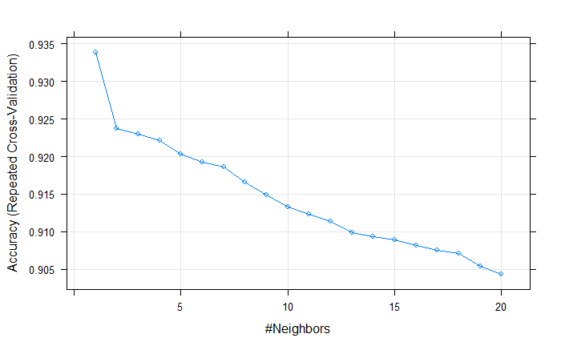

```r
plot(knnModel3)
```

## Tomorrow

1. Try the methods in the Statistical learning book
2. Try out some association models for this problem